## Assignment 3

# Twitter Trend Decay - An analysis of the declining trend of #EgyptAir

### Nina Bartmann (517260)

### Joelle Duff (361872)

### Irene Laureijs (508695)

[figure not shown]

# RESEARCH QUESTION

How long does it take before the Twitter trend in #EgyptAir ceases to exist?

# MOTIVATION & INTRODUCTION

Social Media – a phenomenon of the 21st century. To some it is a red flag, but to most it represents an opportunity to engage in communication and to exchange information. Social media platforms include the social network Facebook, the video-sharing website [YouTube](https://www.youtube.com), the networking service LinkedIn, the mobile photo-sharing service [Instagram](https://www.instagram.com) or the microblogging service Twitter. Social media enables participants of its services or networks to simultaneously be producer, distributor and consumer of information. This means that users of social media engage in a flow of information on a scale and at a speed that were previously not possible.

Within seconds of their occurrence, many news events become extremely popular among social media participants. This is especially visible in relation to disaster news, such as the terror attacks in Paris and [Brussels](http://www.bbc.com/news/blogs-trending-35872170). The intense media coverage right after the attacks captured our interest. People around the world shared their views and expressed solidarity with the victims and their families.

Given the constant flow of information, social media participants are likely to exhibit a limited attention span towards a single topic and are more prone to the symptom of “Quick News”. Hence, we are interested as to how quickly trends in social media can disappear again.

We will investigate and predict how long it will take for the trend in the Twitter hashtag #EgyptAir to disappear. The hashtag refers to an Egypt Air flight, which was hijacked on March 29 2016.

## What is Twitter?

Twitter is an online microblogging service, which enables users to send and read short 140-character messages called “tweets”. Each user chooses to follow certain other users and their “tweets” about news, personal information or links to content such as images, video or articles. Hastags “#” are used to group posts together by a certain topic. “As of May 2015, Twitter has more than 500 million users, out of which more than 332 million are active.” (see: https://en.wikipedia.org/wiki/Twitter)

## METHOD

*Twitter data mining and resulting data points*

For this assignment we were able to mine from Twitter at various hours on Tuesday 29 March 2016, Friday 1 April 2016 and Tuesday 4 April 2016. We found the hashtag #EgyptAir to be trending that day, so we are going to analyze the frequency of mentioning this hashtag (and similar ones) at multiple time periods. Furthermore, we are going to predict the decay in the frequency of the hashtag #EgyptAir by employing a **linear** as well as an **exponential** decay model.

## PRELIMINARY ANSWERS

Our conclusion is that the hashtag #EgyptAir will cease to exist on different dates depending on the model employed. Given that an exponential decay model fits the data best, the answer to our research question is that the hashtag #EgyptAir will either cease to exist on April 2 at 11.00 or on April 3 at 20.00.

# IMPORTING DATA

The following steps were taken to get the data we needed from Twitter:

**Step 1**: Import the real-time data from Twitter

```python
# This command tells python to import data from Twitter, using the package twitter and our personal token codes.
import twitter

consumer_key = 'qwciG2GP5XcIu66v2xjW1HMzX'
consumer_secret = '8Bzy3ve28bErN3YTvCMdeiKSJsTF49Vo6I0SZIUoKorbMCUzsx'
oauth_token = '2456869753-S4bVmPGl7rhunfPMClCCCHpKgBUQFUbdU4fxrBP'
oauth_token_secret = 'nZwv5JjI8Pc5jfZbYujQGZdZ9baZISE4JKQAGtfjYgR4q'

auth = twitter.oauth.OAuth(oauth_token, oauth_token_secret, consumer_key, consumer_secret)
twitter_api = twitter.Twitter(auth=auth)

print (twitter_api)
```

**Step 2** : Create variables to find twitter users location

```python
# We then went on to creating variables to find the twitter users location ID. We did this for the world and for the US.
# The Yahoo! Where On Earth ID for the entire world is 1.
# See https://dev.twitter.com/docs/api/1.1/get/trends/place and
# http://developer.yahoo.com/geo/geoplanet/

WORLD_WOE_ID = 1
US_WOE_ID = 23424977

# Prefix ID with the underscore for query string parameterization.
# Without the underscore, the twitter package appends the ID value
# to the URL itself as a special case keyword argument.

world_trends = twitter_api.trends.place(_id=WORLD_WOE_ID)
us_trends = twitter_api.trends.place(_id=US_WOE_ID)

print (world_trends)
print
print (us_trends)
```

**Step 3** : Convert the data using the *json* package

```python
# The next step is to import the package json. JSON (JavaScript Object Notation) is a compact, text based format for computers
# to exchange data.
import json

print (json.dumps(world_trends, indent=1))
print
print (json.dumps(us_trends, indent=1))
```

**Step 4** : Show common Twitter trends in the US and the World

```python
# We then show the common trends in the US and the World on Twitter
world_trends_set = set([trend['name']
                        for trend in world_trends[0]['trends']])

us_trends_set = set([trend['name']
                     for trend in us_trends[0]['trends']])

common_trends = world_trends_set.intersection(us_trends_set)

print (common_trends)
```

**Step 5** : Focus on the twitter trend *#EgyptAir*

```python
# We can now look for the trending topic, #EgyptAir

q = '#EgyptAir'

count = 100

# See https://dev.twitter.com/docs/api/1.1/get/search/tweets

search_results = twitter_api.search.tweets(q=q, count=count)

statuses = search_results['statuses']
# Iterate through 5 more batches of results by following the cursor

for _ in range(5):
    print ("Length of statuses", len(statuses))
    try:
        next_results = search_results['search_metadata']['next_results']
    except KeyError as e:
        break

# Create a dictionary from next_results, which has the following form:
# ?max_id=313519052523986943&q=NCAA&include_entities=1
    kwargs = dict([ kv.split('=') for kv in next_results[1:].split("&") ])

    search_results = twitter_api.search.tweets(**kwargs)
    statuses += search_results['statuses']

# Show one sample search result by slicing the list...
print (json.dumps(statuses[0], indent=1))
```

**Step 6** : Search for the hashtag *#EgyptAir* in status texts, screennames, and hashtags

```python
status_texts = [ status['text']
                 for status in statuses ]

screen_names = [ user_mention['screen_name']
                 for status in statuses
                     for user_mention in status['entities']['user_mentions'] ]

hashtags = [ hashtag['text']
             for status in statuses
                 for hashtag in status['entities']['hashtags'] ]

# Compute a collection of all words from all tweets
words = [ w
          for t in status_texts
              for w in t.split() ]

# Explore the first 5 items for each...

print (json.dumps(status_texts[0:5], indent=1))
print (json.dumps(screen_names[0:5], indent=1))
print (json.dumps(hashtags[0:5], indent=1))
print (json.dumps(words[0:5], indent=1))
```

**Step 7** : Find the frequency of *#EgyptAir* in the Twitter statusses, screennames, and hashtags

```python
# We count the observations of #EgyptAir by doing the following
from collections import Counter

for item in [words, screen_names, hashtags]:
    c = Counter(item)
    print (c.most_common()[:10]) # top 10
    print
```

**Step 8** : Finally, present the frequencies in a table

```python
from prettytable import PrettyTable

for label, data in (('Word', words),
                    ('Screen Name', screen_names),
                    ('Hashtag', hashtags)):
    pt = PrettyTable(field_names=[label, 'Count'])
    c = Counter(data)
    [ pt.add_row(kv) for kv in c.most_common()[:10] ]
    pt.align[label], pt.align['Count'] = 'l', 'r' # Set column alignment
    print (pt)
```

# Descriptive Statistics

```python
# We use the package Pandas to create the tables below
import pandas as pd
import numpy as np
import matplotlib.pyplot as plt
pd.set_option('max_columns', 50)
%matplotlib inline
```

```python
data = {'Time 0': ['EgyptAir', 'Egyptair', 'SelfiesOutOfControl', 'CBC', 'EgyptAirHijack', 'MS181', 'egyptair', 'weightloss'],
        'Frequency 0': [185, 14, 5, 5, 5, 5, 1, 1],
        'Time 1' : ['EgyptAir', 'EgyptAirHijack', 'Egypt', 'LoveIsInTheAir', 'MS181', 'medias', 'HijackedPlane', 'Cipro'],
        'Frequency 1': [80, 5, 3, 2, 2, 1, 1, 1],
        'Time 2': ['EgyptAir', 'MS181', 'EgyptAirHijack', 'SriLanka', 'inspiration', 'TPMP', 'sbbservicescout', 'AlliAbajo7'],
        'Frequency 2': [62, 2, 2, 1, 1, 1, 1, 1],
        'Time 3': ['EgyptAir', 'Selfies', 'therepost', 'MS181', 'Cyprus', 'ShayGiven', '-', '-'],
        'Frequency 3': [137, 4, 4, 4, 3, 2, '-', '-'],
        'Time 4': ['EgyptAir', 'TrailerJamShow', 'Egyptair', 'USMNT', 'FirstDates', 'AUSvJOR', '-', '-'],
        'Frequency 4': [89, 14, 8, 1, 1, 1, '-', '-']}
EgyptAirCountTotal = pd.DataFrame(data, columns=['Time 0', 'Frequency 0', 'Time 1', 'Frequency 1', 'Time 2', 'Frequency 2',
                                                 'Time 3', 'Frequency 3', 'Time 4', 'Frequency 4'])
EgyptAirCountTotal
```

|  | Time 0 | Frequency 0 | Time 1 | Frequency 1 | Time 2 | Frequency 2 | Time 3 | Frequency 3 | Time 4 | Frequency 4 |
| --- | --- | --- | --- | --- | --- | --- | --- | --- | --- | --- |
| 0 | EgyptAir | 185 | EgyptAir | 80 | EgyptAir | 62 | EgyptAir | 137 | EgyptAir | 89 |
| 1 | Egyptair | 14 | EgyptAirHijack | 5 | MS181 | 2 | Selfies | 4 | TrailerJamShow | 14 |
| 2 | SelfiesOutOfControl | 5 | Egypt | 3 | EgyptAirHijack | 2 | therepost | 4 | Egyptair | 8 |
| 3 | CBC | 5 | LoveIsInTheAir | 2 | SriLanka | 1 | MS181 | 4 | USMNT | 1 |
| 4 | EgyptAirHijack | 5 | MS181 | 2 | inspiration | 1 | Cyprus | 3 | FirstDates | 1 |
| 5 | MS181 | 5 | medias | 1 | TPMP | 1 | ShayGiven | 2 | AUSvJOR | 1 |
| 6 | egyptair | 1 | HijackedPlane | 1 | sbbservicescout | 1 | - | - | - | - |
| 7 | weightloss | 1 | Cipro | 1 | AlliAbajo7 | 1 | - | - | - | - |

### Frequency Tables

```python
# This table shows the frequencies of #EgyptAir from Time 0 to Time 4
data = {'EgyptAir': [185, 80, 62, 137, 89]}
EgyptAirCountTime = pd.DataFrame(data, columns=['EgyptAir'])
EgyptAirCountTime
```

|  | EgyptAir |
| --- | --- |
| 0 | 185 |
| 1 | 80 |
| 2 | 62 |
| 3 | 137 |
| 4 | 89 |

```python
# This table shows the frequencies of #EgyptAirHijack from Time 0 to Time 2
data = {'EgyptAirHijack': [5, 5, 2]}
EgyptAirHijackCountTime = pd.DataFrame(data, columns=['EgyptAirHijack'])
EgyptAirHijackCountTime
```

|  | EgyptAirHijack |
| --- | --- |
| 0 | 5 |
| 1 | 5 |
| 2 | 2 |

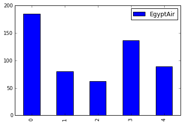

```python
my_plot = EgyptAirCountTime.plot(kind='bar')
```

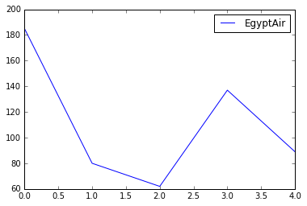

```python
my_plot = EgyptAirCountTime.plot(kind='line')
```

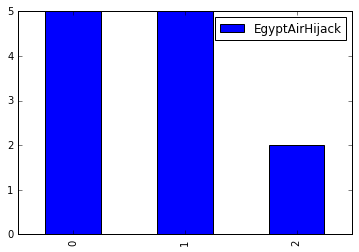

```python
my_plot = EgyptAirHijackCountTime.plot(kind='bar')
```

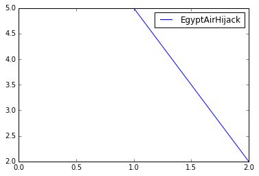

```python
my_plot = EgyptAirHijackCountTime.plot(kind='line')
```

# MODELS

We now need a model which fits our graphs best. We consider using a **linear** or an **exponential** decay function, as shown in the image below.

[figure not shown]

## ASSUMPTIONS

We make the following assumptions and decisions when creating fitting models:

- No new information regarding #EgyptAir or the hijacking in general become available after the initial news. This assumption prevents the hashtag to trend again once the decay has started
- Time periods are spaced out equally
- The decay will happen within a short period of time, such as a few days

# RESULTS

From now on we are going to analyse the data from #EgyptAir only since there is far too little data for #EgyptAirHijack. Given the information we have for the first three time periods, we can fill in the linear and exponential models, and compare their predictions with our own findings. We use *Time 0* as the time at *t=0* and therefore as the constant, or intercept. In order to create these two models, we assume the data points in *Time 0, Time 1* and *Time 2* to be true, and use these to create the functions. In a second step, we are going to use our linear and exponential model to predict when the #EgyptAir hashtag will no longer be relevant among Twitter users.

### **Linear**

Based on the frequency table we created earlier, we are going to construct our linear and exponential decay functions which yield the frequencies for the hashtag #EgyptAir at any given time period. For these functions we use the frequencies in *Time 0* as the intercept value, so $a = 185$. Additionally, we need to calculate the value of $b$, by comparing data from (1) *Time 1* to *Time 0* and (2) from *Time 2* to *Time 0*. Below you will find the calculations for two linear decay functions with different values of $b$.

- we solve the function $y=185-bx$ for $y=80$ and $x=1$ (so at *Time 1*). The following command returns $b=105$. This leads us to our first linear decay function: $$ y_{EgyptAirLinear1} = 185 - 105x $$

```python
from sympy.solvers import solve
from sympy import Symbol
b = Symbol('b')
solve( 185-b-80, b )
```

```
[105]
```

- we solve the function $y=185-bx$ for $y=62$ and $x=2$. The command below returns $b=61.5$. This leads us to our second linear decay function $$y_{EgyptAirLinear2} = 185 - 61.5x$$.

```python
from sympy.solvers import solve
from sympy import Symbol
b = Symbol('b')
solve( 185-62-2*b, b )
```

```
[123/2]
```

```python
# We use the package Pandas to create the tables below
import pandas as pd
import numpy as np
import matplotlib.pyplot as plt
pd.set_option('max_columns', 50)
%matplotlib inline

data = {'Model': ['Linear1', 'Linear2'],
        'b-value': [105, 61.5],
        'Function': ['y=185-105x', 'y=185-61.5x']}
LinearModels = pd.DataFrame(data, columns=['Model', 'b-value', 'Function'])
LinearModels
```

|  | Model | b-value | Function |
| --- | --- | --- | --- |
| 0 | Linear1 | 105.0 | y=185-105x |
| 1 | Linear2 | 61.5 | y=185-61.5x |

The graph below shows us the actual frequency of hashtags (*EgyptAirActual*), as well as the first and second attempt for linear models (*EgyptAirLinear1* and *EgyptAirLinear2*)

```python
import plotly.plotly as py
py.sign_in('ninabartmann', 'm2ua1wueft')
import plotly.graph_objs as go

# Add data
Time = ['Time 0', 'Time 1', 'Time 2', 'Time 3', 'Time 4']
EgyptAirActual = [185, 80, 62, 137, 89]
EgyptAirLinear1 = [185, 123.5, 62.5, 0.5, -61]
EgyptAirLinear2 = [185, 80, -25, -130, -235]

# Create and style traces
Time0 = go.Scatter(
    x = Time,
    y = EgyptAirActual,
    name = 'EgyptAirActual',
    line = dict(
        color = ('rgb(20, 120, 24)'),
        width = 4)
)
Time1 = go.Scatter(
    x = Time,
    y = EgyptAirLinear1,
    name = 'EgyptAirLinear1',
    line = dict(
        color = ('rgb(22, 96, 167)'),
        width = 4,)
)
Time2 = go.Scatter(
    x = Time,
    y = EgyptAirLinear2,
    name = 'EgyptAirLinear2',
    line = dict(
        color = ('rgb(205, 12, 24)'),
        width = 4,)
)

data = [Time0, Time1, Time2]

# Edit the layout
layout = dict(title = 'EgyptAirModels',
              xaxis = dict(title = 'Time'),
              yaxis = dict(title = 'Frequency'),
              )

# Plot and embed in ipython notebook!
fig = dict(data=data, layout=layout)
py.iplot(fig, filename='styled-line')
```

```
High five! You successfuly sent some data to your account on plotly. View your plot in your browser at https://plot.ly/~ninabartmann/0 or inside your plot.ly account where it is named 'styled-line'
```

[interactive chart not shown]

### **Exponential**

Based on the frequency table we created earlier, we are going to construct our exponential decay function for the hashtag #EgyptAir which will model the decay of frequencies exponentially. For this function we use the intercept of $a = 185$ again. The value of b can take on many different values. We are interested in the predictions of the exponential decay model when the function $y=ab^x$ takes on the following values for $b$: 0.1, 0,2, 0.3, 0.4, 0.5, 0.6, 0.7, 0.8, 0.9, and 1. The following command returns the corresponding $y$-values. One of the functions could then look something like this: $$ y_{EgyptAir} = 185*0.7^x $$

```python
y = Symbol('y')
solve( y-185*0.1**0, y )
```

```
[185.000000000000]
```

```python
y = Symbol('y')
solve( y-185*0.1**1, y )
```

```
[18.5000000000000]
```

```python
y = Symbol('y')
solve( y-185*0.2**1, y )
```

```
[37.0000000000000]
```

```python
y = Symbol('y')
solve( y-185*0.3**1, y )
```

```
[55.5000000000000]
```

We can continue doing this for all values of $b$ and $x$. To save space we have summarized the results in the following table. The columns show the possible values for b and the rows indicates the possible time values. The values shown in the table are the *y-values* that correspond to the *b-values* at *Time 0, Time 1, Time 2*.

```python
data = {'b=0.1': [185, 18.5, 1.85],
        'b=0.2': [185, 37, 7.4],
        'b=0.3': [185, 55.5, 16.65],
        'b=0.4': [185, 74, 29.6],
        'b=0.5': [185, 92.5, 46.5],
        'b=0.6': [185, 111, 66.6],
        'b=0.7': [185, 129.5, 90.65],
        'b=0.8': [185, 148, 118.4],
        'b=0.9': [185, 166.5, 149.05],
        'b=1': [185, 185, 185]}
EgyptAirCountModel = pd.DataFrame(data, columns=['b=0.1', 'b=0.2', 'b=0.3', 'b=0.4', 'b=0.5', 'b=0.6', 'b=0.7', 'b=0.8', 'b=0.9', 'b=1'])
EgyptAirCountModel
```

|  | b=0.1 | b=0.2 | b=0.3 | b=0.4 | b=0.5 | b=0.6 | b=0.7 | b=0.8 | b=0.9 | b=1 |
| --- | --- | --- | --- | --- | --- | --- | --- | --- | --- | --- |
| 0 | 185.00 | 185.0 | 185.00 | 185.0 | 185.0 | 185.0 | 185.00 | 185.0 | 185.00 | 185 |
| 1 | 18.50 | 37.0 | 55.50 | 74.0 | 92.5 | 111.0 | 129.50 | 148.0 | 166.50 | 185 |
| 2 | 1.85 | 7.4 | 16.65 | 29.6 | 46.5 | 66.6 | 90.65 | 118.4 | 149.05 | 185 |

We will now use these values to calculate the 10 exponential functions, with varying *b-values*, and plot them into a graph.

```python
import plotly.plotly as py
py.sign_in('JoelleDuff', '2nzyc71ezu')
import plotly.graph_objs as go

# Add data
Time = ['Time 0', 'Time 1', 'Time 2']
BAc = [185, 80, 62]
B01 = [185, 18.5, 1.85]
B02 = [185, 37, 7.4]
B03 = [185, 55.5, 16.65]
B04 = [185, 74, 29.6]
B05 = [185, 92.5, 46.5]
B06 = [185, 111, 66.6]
B07 = [185, 129.5, 90.65]
B08 = [185, 148, 118.4]
B09 = [185, 166.5, 149.05]
B1 = [185, 185, 185]


# Create and style traces
TimeAc = go.Scatter(
    x = Time,
    y = BAc,
    name = 'Actual',
    line = dict(
        color = ('rgb(20, 20, 24)'),
        width = 4)
)

Time01 = go.Scatter(
    x = Time,
    y = B01,
    name = 'B=0.1',
    line = dict(
        color = ('rgb(22, 96, 167)'),
        width = 4,
        dash = 'dash')
)
Time02 = go.Scatter(
    x = Time,
    y = B02,
    name = 'B=0.2',
    line = dict(
        color = ('rgb(22, 96, 167)'),
        width = 4,
        dash = 'dash')
)
Time03 = go.Scatter(
    x = Time,
    y = B03,
    name = 'B=0.3',
    line = dict(
        color = ('rgb(22, 96, 167)'),
        width = 4,
        dash = 'dash')
)

Time04 = go.Scatter(
    x = Time,
    y = B04,
    name = 'B=0.4',
    line = dict(
        color = ('rgb(22, 96, 167)'),
        width = 4,
        dash = 'dash')
)
Time05 = go.Scatter(
    x = Time,
    y = B05,
    name = 'B=0.5',
    line = dict(
        color = ('rgb(22, 96, 167)'),
        width = 4,
        dash = 'dash')
)
Time06 = go.Scatter(
    x = Time,
    y = B06,
    name = 'B=0.6',
    line = dict(
        color = ('rgb(22, 96, 167)'),
        width = 4,
        dash = 'dash')
)
Time07 = go.Scatter(
    x = Time,
    y = B07,
    name = 'B=0.7',
    line = dict(
        color = ('rgb(22, 96, 167)'),
        width = 4,
        dash = 'dash')
)
Time08 = go.Scatter(
    x = Time,
    y = B08,
    name = 'B=0.8',
    line = dict(
        color = ('rgb(22, 96, 167)'),
        width = 4,
        dash = 'dash')
)
Time09 = go.Scatter(
    x = Time,
    y = B09,
    name = 'B=0.9',
    line = dict(
        color = ('rgb(22, 96, 167)'),
        width = 4,
        dash = 'dash')
)
Time1 = go.Scatter(
    x = Time,
    y = B1,
    name = 'B=1',
    line = dict(
        color = ('rgb(22, 96, 167)'),
        width = 4,
        dash = 'dash')
)


data = [TimeAc, Time01, Time02, Time03, Time04, Time05, Time06, Time07, Time08, Time09, Time1]

# Edit the layout
layout = dict(title = 'EgyptAir Exponential Models',
              xaxis = dict(title = 'Time'),
              yaxis = dict(title = 'Frequency'),
              )

# Plot and embed in ipython notebook!
fig = dict(data=data, layout=layout)
py.iplot(fig, filename='styled-line')
```

```
High five! You successfuly sent some data to your account on plotly. View your plot in your browser at https://plot.ly/~JoelleDuff/0 or inside your plot.ly account where it is named 'styled-line'
```

[interactive chart not shown]

# Predictions: Exponential Model

As can be seen from the graph above, the exponential decay funcation seems to fit best with a value for b near 0.5 or 0.6. We will therefore use the following functions:

$$ y = 185*0.5^x$$

and $$ y = 185*0.6^x$$

Using these functions we will now attempt to predict when the trend will cease to exist, so when the frequencies are 0. Because we are looking at exponential functions, we cannot set $y = 0$ to find the intercept. Instead, we will set $y = 0.0000001$ and solve both functions for this value.

```python
x = Symbol('x')
solve( 185*0.5**x-0.0000001, x )
```

```
[30.7848781247278]
```

```python
x = Symbol('x')
solve( 185*0.6**x-0.0000001, x )
```

```
[41.7724767186146]
```

For the values of b equal to 0.5 and 0.6, we find $y = 30.78$ and $y = 41.77$ respectively. This indicates that the trend would cease to exist at time 31 and 42 respectively. Since one unit of time counts for 3 hours, and *Time 0* is at 14.00 on March 29 2016, this means that *Time 31* and *Time 42* are on **April 2 11.00** and **April 3 20.00** respectively.

These predictions can be seen in the graph below where the blue line represents: $ y = 185*0.5^x$ and the red line represents: $ y = 185*0.6^x$ The vertical lines represent *Time 31* and *Time 42* respectively at which $y = 0.0000001$ and the trend will cease to exist.

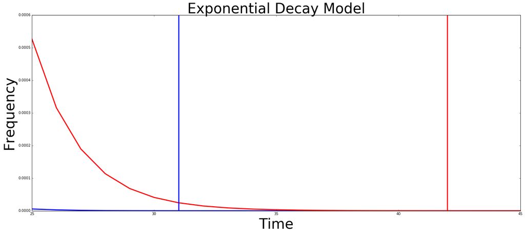

```python
from scipy import optimize, arange
from numpy import array
import matplotlib.pyplot as plt
%matplotlib inline

plt.figure(figsize=(25,10))
x = np.arange(25, 46, 1);
y = (185*(0.5**(x)))
z = (185*(0.6**(x)))
plt.plot(x, y, linewidth = 3)
plt.plot(x, z, color = 'r', linewidth = 3)
plt.title("Exponential Decay Model", fontsize = 40)
plt.xlabel("Time", fontsize = 40)
plt.ylabel("Frequency", fontsize = 40)
plt.axvline(31,color='b', linewidth = 3)
plt.axvline(42,color='r', linewidth = 3)
```

# Predictions: Linear Model

Based on our earlier calculations, we found two linear decay functions: The first linear decay function is: $$ y_{EgyptAirLinear1} = 185 - 105x $$ The second linear decay function is: $$y_{EgyptAirLinear2} = 185 - 61.5x$$ Using these functions, we will now attempt to predict when the trend in #EgyptAir will cease to exist, so when the frequencies are 0. We will set $y = 0$ to find the value for $x$, the time.

```python
x = Symbol('x')
solve (185 - 105*x, x)
```

```
[37/21]
```

```python
x = Symbol ('x')
solve (185 - 61.5*x, x)
```

```
[3.00813008130081]
```

For the first linear decay function, we find that at time $x = 1.76, y =0$. For the second linear decay function, we find that at time $x = 3, y = 0$. This indicates that the trend would cease to exist at time 1.76 and 3 respectively. Again, since one unit of time counts for 3 hours, and *Time 0* is at 14.00 on March 29 2016, *Time 1.76* and *Time 3* are on **March 29 19.15** and **March 29 23.00** respectively.

# CONCLUSION

In order to answer the research question as to how long it will take before the Twitter trend in #EgyptAir will cease to exist, we have looked at two different models: a linear decay model and an exponential decay model.

The linear decay model predicts that the hashtag will cease to exist in the evening of March 29, the same day of the hijacking. The exponential decay model predicts that the hashtag will either cease to exist on April 2 at 11.00 or on April 3 at 20.00.

Given our main assumption, we conclude that our exponential decay model gives the most reliable results. Even though modern society tends towards shorter attention spands, we do not expect that disaster events will only be relevent to Social Media for a few hours. A span of several days seems much more plausible.

# Discussion

We are now going to shortly elaborate on our findings and discuss some elements on which we needed additional information.